# Hjemmeoppgaver

# Verdsetting av kraftselskap

**Viktig:** Det er ikke et mål i seg selv at alle skal bli ferdig med alle funksjoner. Lag så mange du klarer, og husk at det er mye bedre å skrive gode tester og dokumentasjon for en funksjon, enn å bli ferdig med alle funksjoner, men uten tester og dokumentasjon.

Lag hjelpefunksjoner der det trengs. Husk å gi både funksjoner og variabler fornuftige navn.

De fleste funksjonene er ment å bruke i en viss rekkefølge, og per år. Det kan derfor være naturlig å skrive funksjonene slik at de kan brukes i en pipe på en data.frame. Det er valgfritt om en ønsker å gjøre det på denne måten, eller skrive mer “uavhengige” funksjoner. Dette vil trolig kreve litt mer arbeid for brukeren av pakken.

## Hent data

Et viktig steg i prosessen for å verdsette et kraftselskap er å predikere fremtidige inntekter. Årlig kraftproduksjon er derfor en viktig variabel. Dette er tilgjengelig for alle kraftverk i Norge her: https://www.nve.no/energiforsyning/vannkraft/vannkraftdatabase. Ved å trykke på “Eksporter hele listen” kan man laste ned en CSV-fil med nøkkeltall over alle vannkraftverkene i Norge.

Vi ønsker en enklere måte å laste ned disse dataene enn å måtte gå manuelt inn på siden, laste ned hele listen som en csv-fil, lagre den i riktig mappe for så å laste den inn til R.

En bedre fremgangsmåte er å bruke et API for å laste inn denne dataen. URL’en til APIet er: https://www.nve.no/umbraco/api/Powerplant/GetHydroPowerPlantsInOperation

Her skal du lage 2 funksjoner:

- En funksjon (uten input) som benytter APIet til å returnere dataene fra CSV-filen som en data.frame.
- En funksjon som tar inn denne data.frame-en samt navnet på et kraftverk, og returner årlig kraftproduksjon for det aktuelle kraftverket.

**Husk** å lage funksjonene i en pakke. Lag dokumentasjon og tester.

**Hint:** APIet returnerer dataene på JSON-format. Man kan bruke `jsonlite::fromJSON()` for å tolke dette formatet.

**Hint 2:** Variabelen “MidProd_81_10” viser gjennomsnittlig kraftproduksjon mellom 1981 og 2010 i GWh (= 1 000 000 kWh). Dette er et godt mål på årlig kraftproduksjon.

Obs: Det er god praksis å begrense antall API-kall. Ikke spam NVE. Dette er særlig viktig for testene av funksjonen.

## Beregn inntekter

### Legg til data i pakken.

Lagre disse verdiene som et datasett i pakken:

```r
tibble::tibble(date = seq(lubridate::as_date("2019-12-31"), lubridate::as_date("2040-12-31"), by = "year"),
               power_price = c(0.30, 0.32, 0.35, 0.37, 0.38, 0.40, 0.41, 0.43, 0.43, 0.43, 0.43, 0.43, 0.43, 0.43, 0.43, 0.43, 0.43, 0.43, 0.43, 0.43, 0.43, 0.43))
```

```
## # A tibble: 22 x 2
##    date       power_price
##    <date>           <dbl>
##  1 2019-12-31        0.3
##  2 2020-12-31        0.32
##  3 2021-12-31        0.35
##  4 2022-12-31        0.37
##  5 2023-12-31        0.38
##  6 2024-12-31        0.4
##  7 2025-12-31        0.41
##  8 2026-12-31        0.43
##  9 2027-12-31        0.43
## 10 2028-12-31        0.43
## # ... with 12 more rows
```

- `date` gir siste dag i året for hvert år mellom 2019 og 2040.
- `power_price` viser forventede kraftpriser (prisbanen) i NOK/kWh.

Utvid tabellen til å gå 80 år frem i tid før du lagrer den. La `power_price` være 0.43 i de årene.

### Beregn inntekter

Lag en funksjon som tar prisbanen samt årlig produksjon for et kraftverk som input, og returnerer inntekt per år for de årene som er tilgjengelig i prisbanen. Man kan gå ut ifra at årlig kraftproduksjon vil være stabil.

## Kostnader

Lag en funksjon som beregner kostnadene for et kraftverk.

Funksjonen skal ha følgende input-parameter:

- prisbane
- Operating cost per kWH
- Investment per kWh
- Deprecation per kWh
- Årlig kraftproduksjon

Output skal være operating cost, investement cost og deprecation per år, for like mange år som inntektene er beregnet for.

Eksempelverdier for kostnader:

- Operating costs per kWh: 0.30 NOK/kWh
- Investment per kWh: 0.20 NOK/kWh
- Depreciation per KWh: 0.20 NOK/kWh

(Gjerne sett disse verdiene som default-verdier.)

Output fra funksjonen skal være noe slik (men tidy):

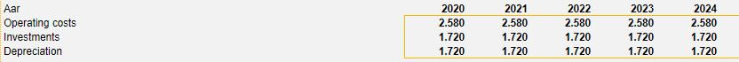

## Finn cashflowen til selskapet

Beregn årlig fri kontantstrømmen (etter skatt) fra drift for et kraftverk ved følgende formel: $Inntekter - Kostnader - Skatt - Investeringer + Avskrivning$

Skattesatsen kan settes til 22% av EBIT (Inntekter - kostnader) som default.

## Weighted average cost of capital

Beregn totalkapitalkostnaden (Weighted Average Cost of Capital - WACC) for et spesifikt kraftverk med følgende formler:

$Equity~beta = Asset~beta \times (1 + \frac{Debt~share}{1 - Debt~Share)})$

$Cost~of~equity = Risk~free~rate + other~adjustments + market~risk~premium \times Equity~beta$

$Cost~of~debt = (Risk~free~rate + Debt~premium) \times (1 - Corporate~income~tax)$

$Cost~of~capital~(WACC) = (Cost~of~equity \times (1 - Debt~share)) + (Cost~of~debt \times Debt~share)$

$Real~cost~of~capital~(WACC) = \frac{1 + Cost~of~capital}{1 + inflation} - 1$

Input parametere bør være (med default-verdier):

- Asset beta: 0.6
- Risk-free rate: 2%
- Market risk premium: 5%
- Other adjustments: 2%
- Debt premium: 2.5%
- Debt share: 50%
- Corporate income tax: 22%
- Inflation: 2%

## Presenter verdien av selskapet

Finn nåverdien av selskapet. Net present value kan regnes ut slik:

$$NPV = \sum_{t=1}^T\frac{cashFlow_t}{(1 + WACC) ^t}$$